# Informe1

# Incremento del consumo de comida por delivery por parte de jóvenes (17-30 años) en Lima metropolitana a raíz de la pandemia

Laboratorio: **5.01**

## Introducción

### Relevancia

Es un claro indicador para emprendimientos o personas que buscan abrir un restaurante, de si realmente vale la pena invertir en un local tradicional de atención directa al cliente, o si es preferible optar únicamente por el concepto de dark kitchen y valerse de un sistema de delivery propio o del servicio que brindan compañías como Rappi o PedidosYa, que son los máximos exponentes de un mercado que se ha disparado a raíz de la pandemia.

### Planificación

Haciendo uso de un diagrama de Gantt detallaremos los avances fecha por fecha que se realizara durante todo el ciclo.

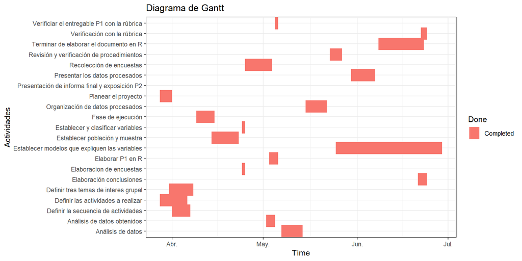

```r
df <- read_csv("planificacion.csv")
ggplot(df, aes(x=Start, xend=End, y=Description, yend=Description,color=Done))+
  theme_bw()+ #use ggplot theme with black gridlines and white background
  geom_segment(size=8) + #increase line width of segments in the chart
  labs(title='Diagrama de Gantt', x='Time', y='Actividades')
```

## Datos

### Proceso de recolección de datos

Se hizo a través de una encuesta dirigida a nuestros familiares, amigos y compañeros de universidad. Se escogió esté método debido a su viabilidad y facilidad de implementación (al no demandar mucho trabajo manual ni costo alguno), además del alto alcance que puede llegar a tener (gracias a su fácil difusión y distribución). En todo momento fuimos conscientes de que había que plantear buenas preguntas y definir cuáles iban a ser estas, ya que las respuestas a estas nos iban a dar la información precisa que necesitábamos para conformar nuestra base de datos en función de nuestras variables. Dentro de las estrategias que aplicamos, estaba la brevedad y simplicidad de la encuesta, pues consideramos que mientras más tiempo demandase al individuo responder la encuesta, menos probabilidades había de que la termine de contestar. Bajo esa lógica, para responder más de una pregunta, incluímos opciones para que simplemente se marque la deseada. Aquello fue una forma en la que condicionamos apropiadamente nuestra encuesta, de tal forma que pudiéramos ahorrarnos el inconveniente de tener que uniformizar las respuestas en un solo formato. Por ejemplo, ciertas personas podrían responder una pregunta con números y otras con palabras o caracteres, lo cual haría más compleja aún la limpieza de datos. Otra estrategia fue la de aprovechar las redes sociales (sobre todo las de mensajería directa, como WhatsApp, Telegram y Discord) para lograr una mayor audiencia, dado lo sencillo que es responder a la encuesta con un simple click en un URL. Y una tercera estrategia fue la de agregar una breve descripción a ciertas preguntas que podrían generar algún tipo de confusión en el encuestado, a manera de evitar ello.

### Variables

La principal comparativa del estudio se dará entre el `consumo por delivery` (en adelante **CD**) y el `consumo presencial` (en adelante **CP**). A su vez, **CD 1** hace referencia al `CD pre-pandemia` y **CD 2** al `CD actual`. Ahora bien, el estudio cuenta con 10 variables:

- `Edad`: edad del encuestado
- `Sexo`: sexo del encuestado
- `Preferencia`: modalidad en la que prefiere consumir la comida de un restaurante
- `Frecuencia CD 1`: número promedio de veces que ordenaba delivery antes de la pandemia por mes
- `Frecuencia CD 2`: número promedio de veces que ordena delivery actualmente por mes
- `Frecuencia CP`: número de veces que acude en promedio a un restaurante actualmente
- `Pago`: rango de precio que está dispuesto a pagar por el servicio de delivery
- `Tiempo`: tiempo promedio que esta dispuesto a esperar por su comida
- `Prioridad`: criterio que prioriza el usuario al escoger un restaurante para consumir por delivery
- `Indispensabilidad`: si el encuestado considera indispensable que un restaurante cuente con servicio de delivery

| Variable | Tipo | Restricciones |
| --- | --- | --- |
| `Edad` | Numérica discreta | Número entero positivo |
| `Sexo` | Categórica nominal | Masculino, Femenino |
| `Frecuencia CD1` | Numérica discreta | Número entero positivo |
| `Frecuencia CD2` | Numérica discreta | Número entero positivo |
| `Frecuencia CP` | Numérica discreta | Número entero positivo |
| `Pago` | Categórica nominal | 1-5 soles, 5-10 soles, más de 10 soles, 0 soles |
| `Tiempo` | Numérica discreta | Número entero positivo (minutos) |
| `Prioridad` | Categórica Nominal | Calidad, Precio Bajo, Tiempo, Otros |
| `Indispensabilidad` | Categórica Nominal | Sí, No |

```r
datos_sin_limpiar <- read_csv("Datos_Delivery.csv")
```

[output not shown]

### Limpieza de datos:

#### Variable “Prioridad”:

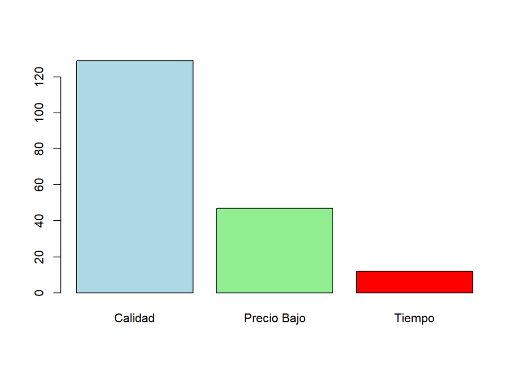

#### Variable “Pago”:

## Análisis descriptivo:

Antes que nada, es importante recalcar que la idea de este estudio es brindar a emprendedores la información suficiente para determinar si es que es necesario que monten un local físico de su restaurante, o si es que se pueden dar el “lujo” de trabajar solamente con delivery y cocina(s) oculta(s). Y todo esto consiste en analizar las preferencias y tendencias de la muestra de estudio. Lo primero a tener en cuenta es qué prefieren las personas. En base a eso, se presenta primero la variable, “Preferencia”, que indica si es que a las personas les gusta más consumir presencialmente (CP) o desde su casa (CD), o si es que les resulta indiferente. A continuación exponemos dicha información porcentualmente:

#### Preferencia: la manera en la que las personas prefieren consumir la comida de un restaurante

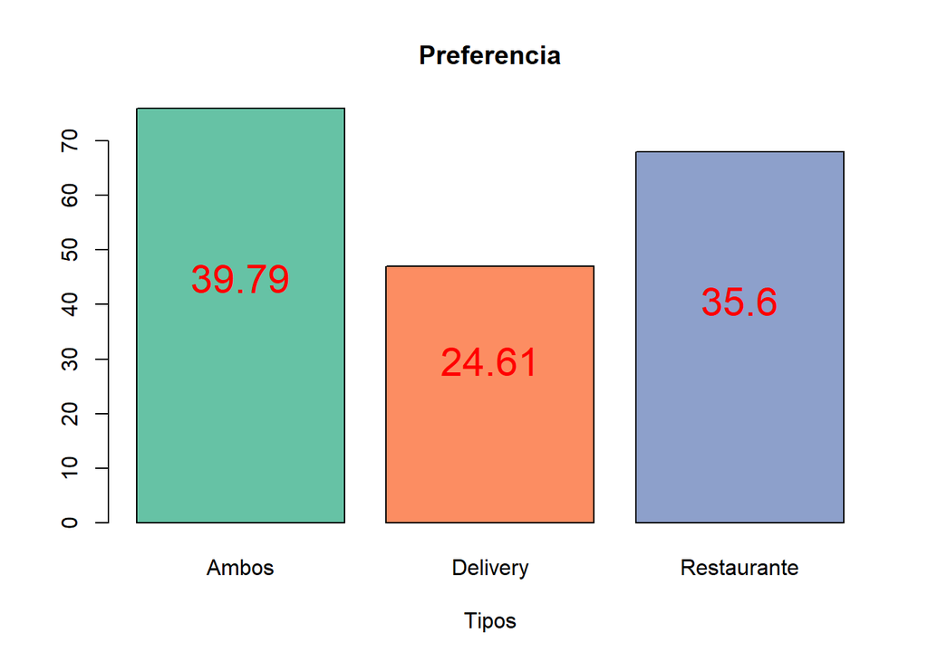

```r
coul <- brewer.pal(5, "Set2")
bb <- barplot(table(datos$Preferencia),
        col = coul,
        main = "Preferencia",
        xlab= "Tipos",
        width = 0.85)
proporcion <- round(table(datos$Preferencia)/nrow(datos)*100, digits=2)
# Agregar texto dentro de los bloques
text(x = bb, y =proporcion , label = proporcion, pos = 3,  cex = 1.8,col = "red")
```

```r
#(table(datos$Preferencia)/nrow(datos)*100, digits=2)
```

#### Indispensabilidad: si las personas consideran indispensable que un restaurante cuente con delivery o no

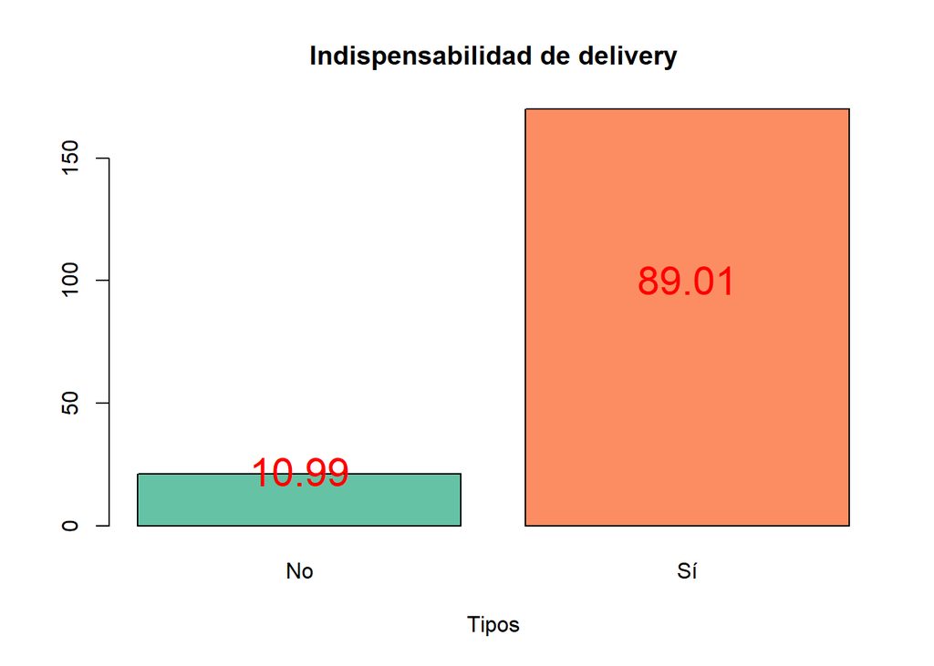

```r
coul <- brewer.pal(4, "Set2")
bb <- barplot(table(datos$Indispensabilidad),
        col = coul,
        main = "Indispensabilidad de delivery",
        xlab= "Tipos",
        width = 0.85)
respuesta <- round(table(datos$Indispensabilidad)/nrow(datos)*100, digits=2)
# Agregar texto dentro de los bloques
text(x = bb, y =respuesta , label = respuesta, pos = 3,  cex = 1.8,col = "red")
```

Una rotunda mayoría opina que sí, por lo que queda comprobado que, por más de que prefieran CP, consideran que el CD tiene que ir de la mano, pues también lo consumen. Justamente ahora, pasada la pandemia, este CD ha aumentado. Las personas ya se acostumbraron a consumir desde su casa y, al mismo tiempo, cada vez son más los restaurantes con cocinas ocultas. Así lo explican los siguientes gráficos, que muestran que, a pesar de que el grueso de personas siga consumiendo entre 0 y 5 veces al mes, hoy son mucho más las personas que lo hacen con mayor frecuencia. Se puede apreciar comparando los histogramas o analizando el diagrama de dispersión:

#### Frecuencia CD1 VS Frecuencia CD2: aumento del consumo a raíz de la pandemia

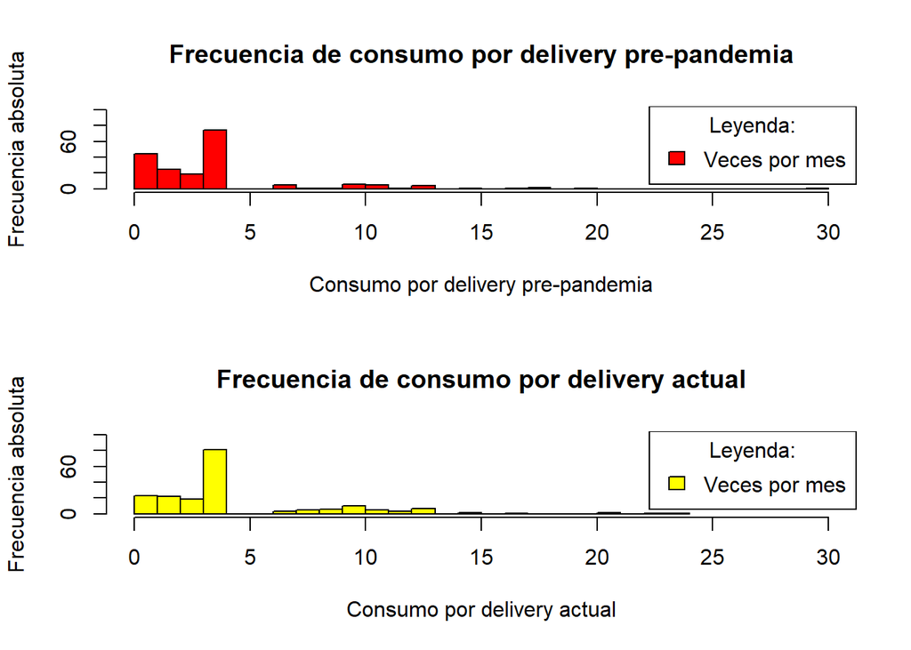

```r
par(mfrow=c(2,1))
hist(datos$`Frecuencia CD1`, main="Frecuencia de consumo por delivery pre-pandemia", xlab="Consumo por delivery pre-pandemia", ylab="Frecuencia absoluta", col="red", xlim=c(0,30), ylim=c(0,100), breaks=30)
legend(x = "topright", legend = c("Veces por mes"), fill = c("red"), title = "Leyenda:")

hist(datos$`Frecuencia CD2`, main="Frecuencia de consumo por delivery actual", xlab="Consumo por delivery actual", ylab="Frecuencia absoluta", col="yellow", xlim=c(0,30), ylim=c(0,100), breaks=30)
legend(x = "topright", legend = c("Veces por mes"), fill = c("yellow"), title = "Leyenda:")
```

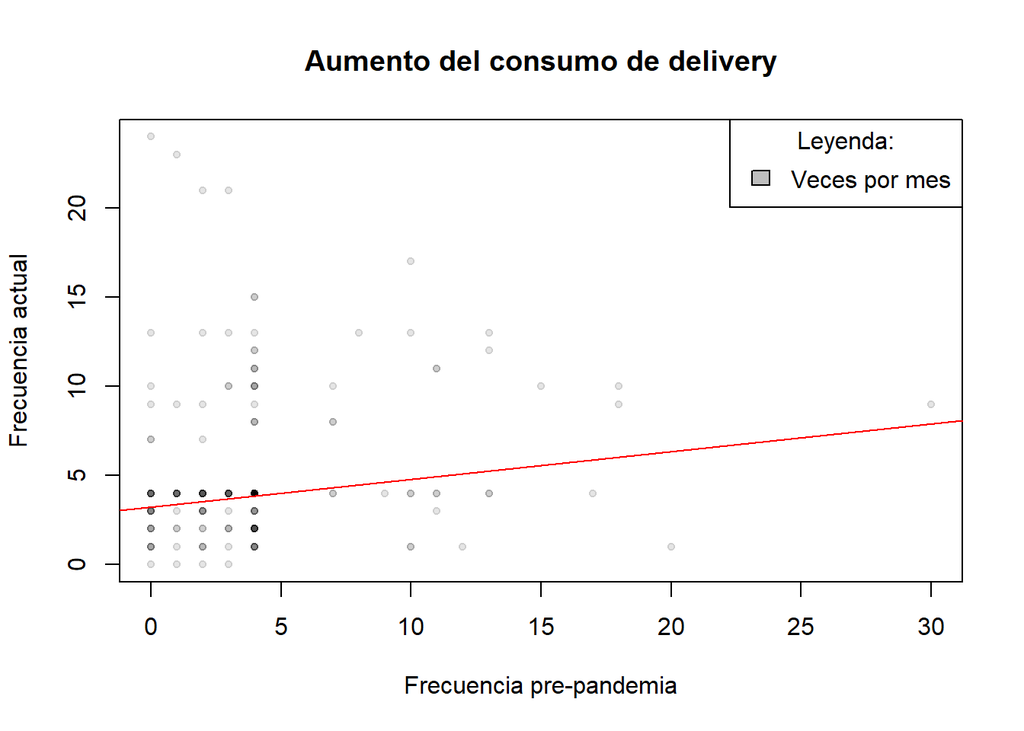

```r
plot(datos$`Frecuencia CD1`, datos$`Frecuencia CD2`, main="Aumento del consumo de delivery", xlab="Frecuencia pre-pandemia", ylab="Frecuencia actual", col=rgb(0,0,0,0.1), pch = 20)
lm1 <- lm(datos$`Frecuencia CD1`~datos$`Frecuencia CD2`)
abline(lm1, col="red")
legend(x = "topright", legend = c("Veces por mes"), fill = c("grey"), title = "Leyenda:")
```

```r
cor(datos$`Frecuencia CD1`,datos$`Frecuencia CD2`)
```

```
## [1] 0.1616379
```

Otra forma de mostrar esta evolución en el CD, es a través de un descriptor numérico como la media. Tal como se verá a continuación, el CD promedio por persona al mes ha aumentado de 4 a 5, lo cual puede parecer poco, pero es un aumento de una unidad por cada persona que consume, lo cual para un restaurante no es nada insignificante. Véase:

#### Frecuencia CD1 VS Frecuencia CD2: media de CD mensual pre-pandemia y actual

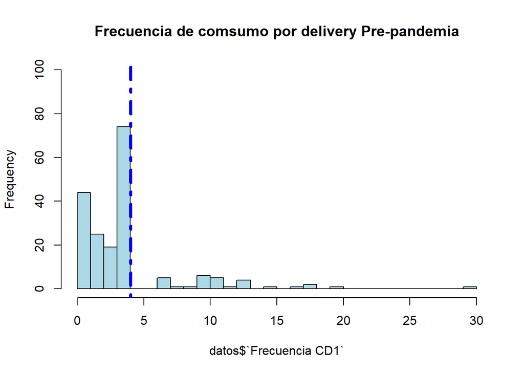

```r
promedioFCD1 <- round(mean(datos$`Frecuencia CD1`), digits=2)
promedioFCD2 <- round(mean(datos$`Frecuencia CD2`), digits=2)
hist(datos$`Frecuencia CD1`, xlim=c(0,30), ylim=c(0,100), breaks=30, main = "Frecuencia de comsumo por delivery Pre-pandemia", col = "lightblue")
abline(v=round(mean(datos$`Frecuencia CD1`), digits=2), col = "blue", lwd=4, lty=4)
```

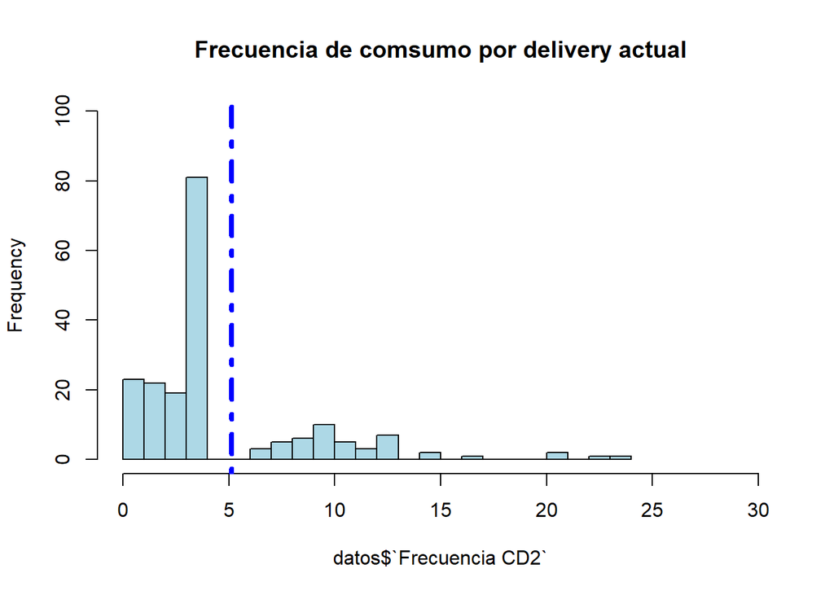

```r
hist(datos$`Frecuencia CD2`, xlim=c(0,30), ylim=c(0,100), breaks=30, main = "Frecuencia de comsumo por delivery actual", col = "lightblue")
abline(v=round(mean(datos$`Frecuencia CD2`), digits=2), col = "blue", lwd=4, lty=4)
```

Ahora bien, el CD actual no solamente supera al CD pre-pandemia, sino que también supera al CP. Si bien esta última es la forma de consumo preferida, no es la más practicada. Si se compara el siguiente histograma con el anterior (que hace referencia al CD actual) se puede concluir lo dicho. El diagrama de dispersión hace lo propio:

#### Frecuencia CP VS Frecuencia CD2: diferencia entre CP y CD

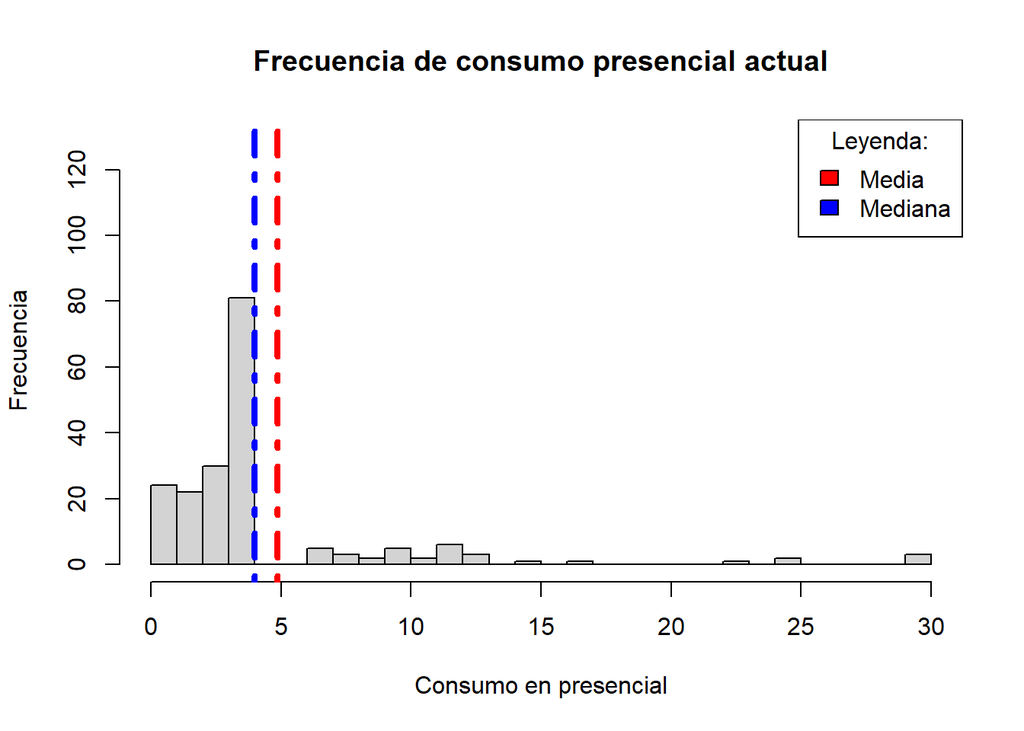

```r
mediaFrecuenciaCD2 <-round(mean(datos$`Frecuencia CD2`), digits=2)
medianaFrecuenciaCD2 <- round(median(datos$`Frecuencia CD2`), digits=2)
mediaFrecuenciaCP <- round(mean(datos$`Frecuencia CP`), digits=2)
medianaFrecuenciaCP <-round(median(datos$`Frecuencia CP`), digits=2)
hist(datos$`Frecuencia CP`,
     xlim=c(0,30),
     ylim=c(0,130),
     breaks=30,
     xlab = "Consumo en presencial",
     ylab="Frecuencia",
     main="Frecuencia de consumo presencial actual")
abline(v=c(mediaFrecuenciaCP, medianaFrecuenciaCP), col = c("red","blue"), lwd=4, lty=4)
legend(x = "topright", legend = c("Media", "Mediana"), fill = c("red", "blue"), title = "Leyenda:")
```

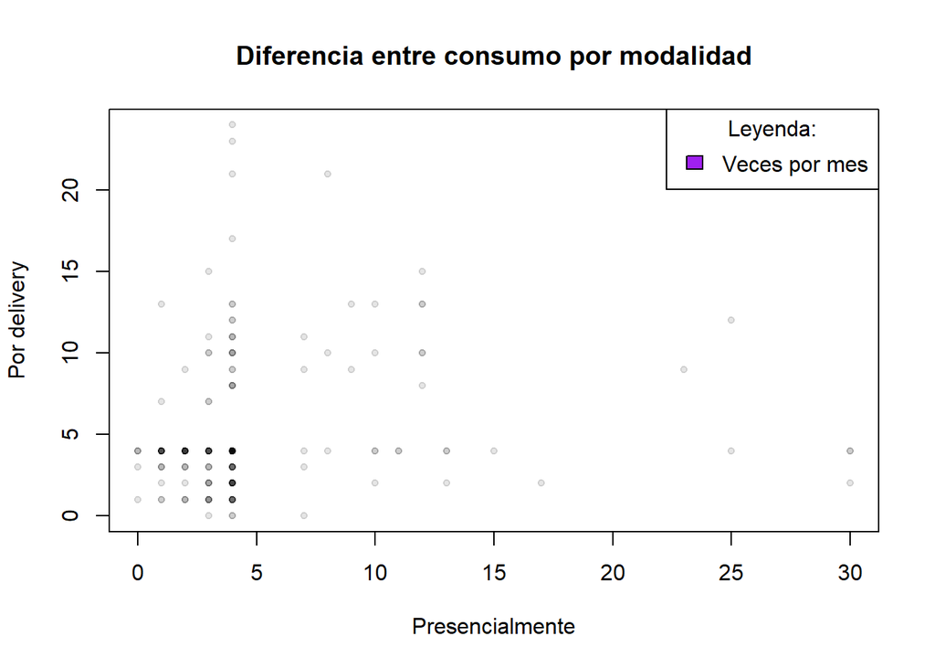

```r
plot(datos$`Frecuencia CP`, datos$`Frecuencia CD2`, main="Diferencia entre consumo por modalidad", xlab="Presencialmente", ylab="Por delivery", col=rgb(0,0,0,0.1), pch = 20)
legend(x = "topright", legend = c("Veces por mes"), fill = c("purple"), title = "Leyenda:")
```

```r
round(mean(datos$`Frecuencia CP`), digits=2)
```

```
## [1] 4.88
```

```r
round(mean(datos$`Frecuencia CD2`), digits=2)
```

```
## [1] 5.12
```

Nuevamente, la media apoya lo graficado. Mientras que la frecuencia de CD es de 5.12 veces al mes por persona, la de CP es menor. En general, hay mayor consumo CD que CP:

#### Frecuencia CD2 VS Frecuencia CP: media de veces al mes que se consume por delivery y presencialmente

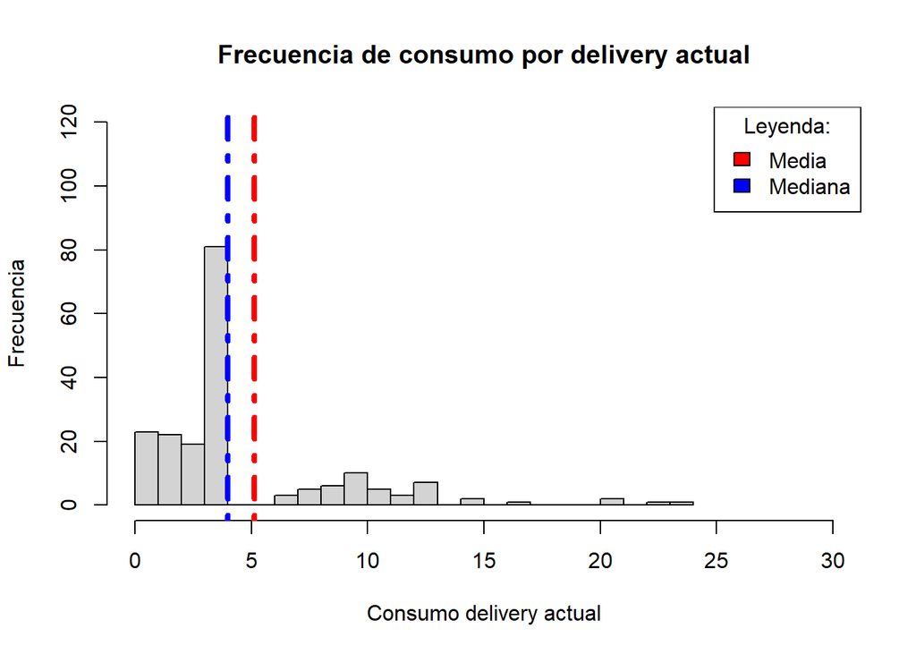

```r
mediaFrecuenciaCD2 <-round(mean(datos$`Frecuencia CD2`), digits=2)
medianaFrecuenciaCD2 <- round(median(datos$`Frecuencia CD2`), digits=2)
mediaFrecuenciaCP <- round(mean(datos$`Frecuencia CP`), digits=2)
medianaFrecuenciaCP <-round(median(datos$`Frecuencia CP`), digits=2)

hist(datos$`Frecuencia CD2`,
     xlim=c(0,30),
     ylim=c(0,120),
     breaks=30,
     xlab = "Consumo delivery actual",
     ylab = "Frecuencia",
     main = "Frecuencia de consumo por delivery actual")
abline(v=c(mediaFrecuenciaCD2, medianaFrecuenciaCD2), col = c("red","blue"), lwd=4, lty=4)
legend(x = "topright", legend = c("Media", "Mediana"), fill = c("red", "blue"), title = "Leyenda:")
```

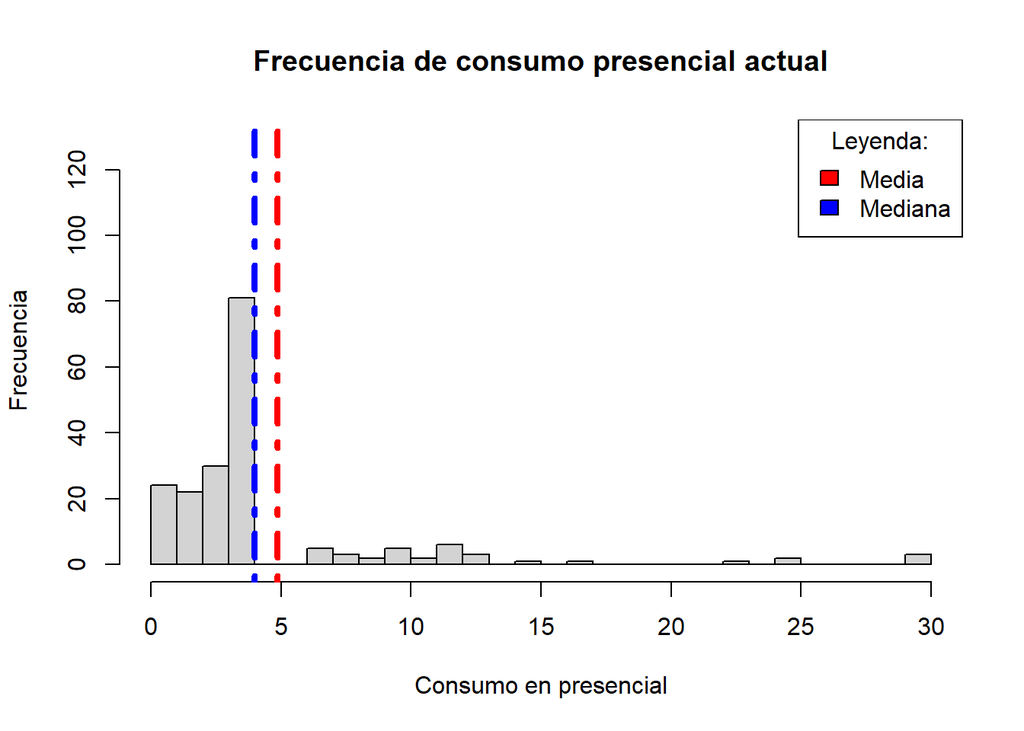

```r
hist(datos$`Frecuencia CP`,
     xlim=c(0,30),
     ylim=c(0,130),
     breaks=30,
     xlab = "Consumo en presencial",
     ylab="Frecuencia",
     main="Frecuencia de consumo presencial actual")
abline(v=c(mediaFrecuenciaCP, medianaFrecuenciaCP), col = c("red","blue"), lwd=4, lty=4)
legend(x = "topright", legend = c("Media", "Mediana"), fill = c("red", "blue"), title = "Leyenda:")
```

```r
round(mean(datos$`Frecuencia CP`), digits=2)
```

```
## [1] 4.88
```

```r
round(mean(datos$`Frecuencia CD2`), digits=2)
```

```
## [1] 5.12
```

Habiendo ilustrado ya que el CD hoy es más popular de lo que era hace dos años y más popular de lo que es hoy el CP, los emprendedores pueden saber que no hace falta brindar esa grata experiencia que implica consumir presencialmente para que el negocio tenga éxito. Sin embargo, el delivery tiene que ir de la mano de ciertas condiciones. Para saber cuáles son ellas, incluímos la variable “Prioridad”, para saber qué era lo que las personas priorizan al escoger el restaurante cuya comida van a consumir desde su casa. A continuación se muestra la distribución de las opiniones:

#### Prioridad: lo que las personas priorizan al escoger un restaurante para consumir por delivery

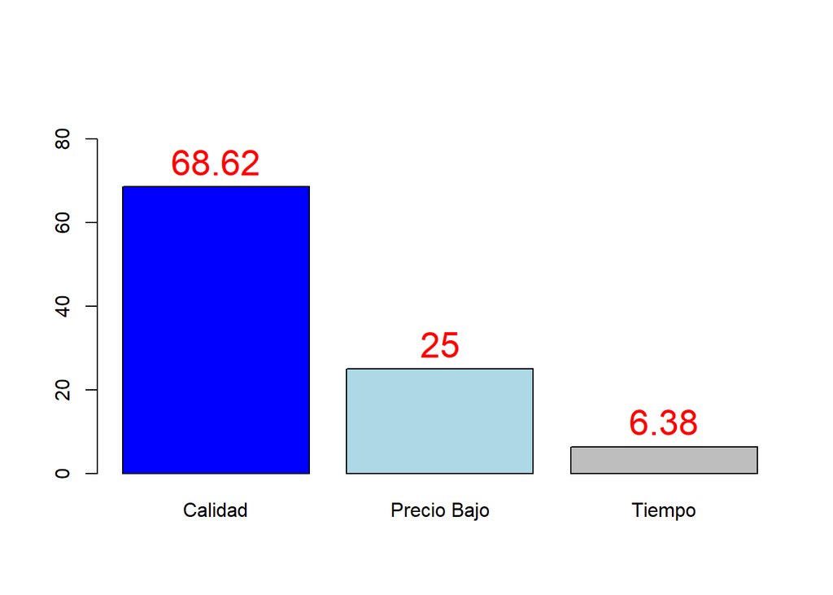

```r
prioridad_porcentaje = round(table(datos$Prioridad)/sum(table(datos$Prioridad))*100, digits=2)
bb <-barplot(prioridad_porcentaje,col = c('blue', 'lightblue', 'grey'), ylim = c(0,90))
text(x = bb, y =prioridad_porcentaje , label = prioridad_porcentaje, pos = 3,  cex = 1.8,col = "red")
```

#### Tiempo: media del tiempo que las personas están dispuestas a esperar por su comida

```r
hist(datos$Tiempo, c=("lightblue"), xlab="Tiempo", main="", ylab="Frecuencia")
abline(v=c(round(mean(datos$Tiempo)), round(median(datos$Tiempo))), col =c("red", "blue"))
sprintf("Media: %.2f", round(mean(datos$Tiempo), digits=2))
```

```
## [1] "Media: 37.59"
```

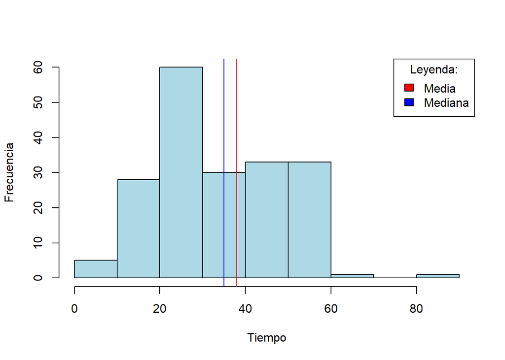

```r
legend(x = "topright", legend = c("Media", "Mediana"), fill = c("red", "blue"), title = "Leyenda:")
```

```r
median(datos$Tiempo)
```

```
## [1] 35
```

```r
mean(datos$Tiempo)
```

```
## [1] 37.58639
```

#### Pago: lo que las personas están dispuestas a pagar por el cargo del delivery (por porcentajes)

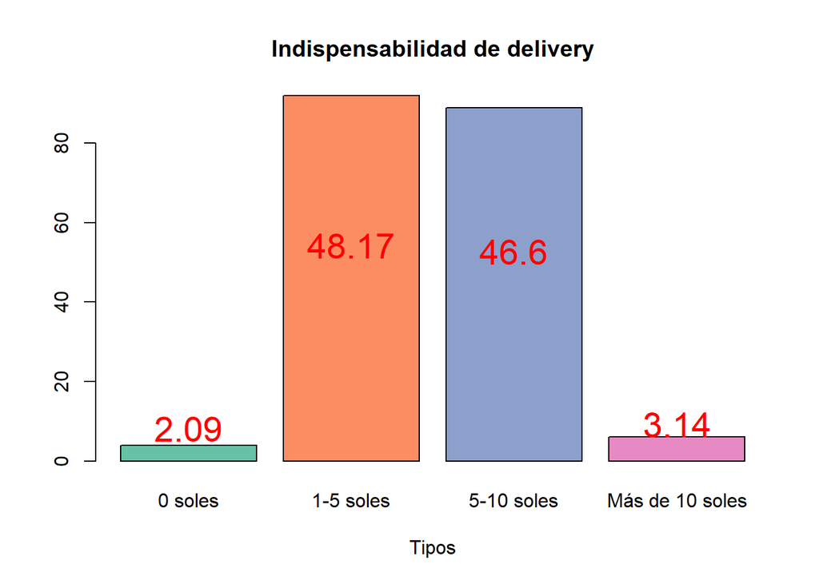

```r
coul <- brewer.pal(6, "Set2")
bb <- barplot(table(datos$Pago),
        col = coul,
        main = "Indispensabilidad de delivery",
        xlab= "Tipos",
        width = 0.85)
pagos <- round(table(datos$Pago)/nrow(datos)*100, digits=2)
# Agregar texto dentro de los bloques
text(x = bb, y =pagos , label = pagos, pos = 3,  cex = 1.8,col = "red")
```

Analisis descriptivo: Para este analisis, recurriremos en la evalucion de una mejora economica para el servicio de delivery de un restaurant. Es por eso que nos enfocaremos en la relacion entre la prioridad y el dinero dispuesto a pagar por el delivery.

```r
table(datos$Pago,datos$Prioridad)
```

```
##
##                   Calidad Precio Bajo Tiempo
##   0 soles               1           2      0
##   1-5 soles            65          21      5
##   5-10 soles           58          23      7
##   Más de 10 soles       5           1      0
```

Calculando las probabilidades condicionales de cada propiedad:

```r
p_calidad <- sum(datos$Prioridad == 'Calidad',na.rm=TRUE)/sum(table(datos$Pago,datos$Prioridad))
p_precio <- sum(datos$Prioridad == 'Precio Bajo',na.rm=TRUE)/sum(table(datos$Pago,datos$Prioridad))
p_tiempo <- sum(datos$Prioridad == 'Tiempo',na.rm=TRUE)/sum(table(datos$Pago,datos$Prioridad))
cat('P(calidad):',round(p_calidad,2),'\n')
```

```
## P(calidad): 0.69
```

```r
cat('P(precio):',round(p_precio,2),'\n')
```

```
## P(precio): 0.25
```

```r
cat('P(tiempo):',round(p_tiempo,2),'\n')
```

```
## P(tiempo): 0.06
```

Del calculo de las probabilidades, se puede notar que la probabilidad de calidad es la mas elevada. Consecuentemente, sera las focalizada. Por ejemplo: 1. Si analizados la probabilidad de que una persona este dispuesta a pagar mas de 5 soles, dado que su prioridad es la calidad:

```r
p_calidad_c <- (63/129)
cat('P(X>5|Calidad):',round(p_calidad_c,2),'\n')
```

```
## P(X>5|Calidad): 0.49
```

2. Sacando la probabilidad de que calidad no sea la prioridad:

```r
p_calidad_cc <- (31/59)
cat('P(X>5|Precio\'):',round(p_calidad_cc,2),'\n')
```

```
## P(X>5|Precio'): 0.53
```

Nos damos cuenta de que para valores mayores que 5, la probabilidad de que sea por la calidad esta muy cercana a la que si no lo fuera. Por lo tanto nos podemos guiar de que debido a que la probabilidad de que la prioridad sea la calidad es mas influyente que sus contrapartes.

Modelos de variables aleatorias:

A modo de estimar el crecimiento economico de un restaurante si se enfoca en la calidad de su productos Si se realiza una encuesta para evaluar la economia de un delivery, ¿cual seria la probabilidad de que al elegir a 5 personas, 4 de ellas esten dispuestas a pagar mas de 5 soles y que su prioridad sea la calidad?

```r
m_calidad <- 1-dnbinom(5-4,4,p_calidad_c)+dnbinom(4-4,4,p_calidad_c)
cat('P(X>5):',round(m_calidad,2),'\n')
```

```
## P(X>5): 0.94
```

Una vez hallada la probabilidad, ¿Cuantas personas se esperaria encuestar para que 4 de ellas esten dispuestas a pagar mas de 5 soles y su prioridad sea la calidad?

```r
EX_prioridad <- 4/p_calidad_c
cat('E(X):',round(EX_prioridad,2),'\n')
```

```
## E(X): 8.19
```

Tendriamos que analizar 8 personas para que 4 de ellas priorizen la calidad y que esten dispuestos a pagar mas de 5 soles.

## Conclusiones

En conclusión, por lo aportado con nuestro estudio, es un hecho que los emprendedores no tienen porqué preocuparse en conseguir un capital de inversión tan grande como para montar un local físico, pues no es necesario. El CD es popular, apoyado y muy frecuente en los jóvenes limeños. Mientras el producto sea bueno y las condiciones de tiempo de entrega y cargo por el servicio sean las correctas, la empresa tendrá éxito con esta modalidad.